# Praca domowa 2

Mateusz Jamroż

## Dane

Dane wykorzystane w Pracy domowej 2 opisują wycenę nieruchmości. Każda obserwacja jest pewną nieruchmością, która posiada informacje takie jak powierzchnia, liczba pokoi, liczba łazienek i wiele więcj. Opis wszystkich kolumn w pliku `README.md`.

## Zadanie 1

Jak wygląda rozkład ceny nieruchomości w poszczególnych kodach pocztowych na przestrzeni lat? Rozważamy kody pocztowe, które mają więcej niż 280 posiadłości.

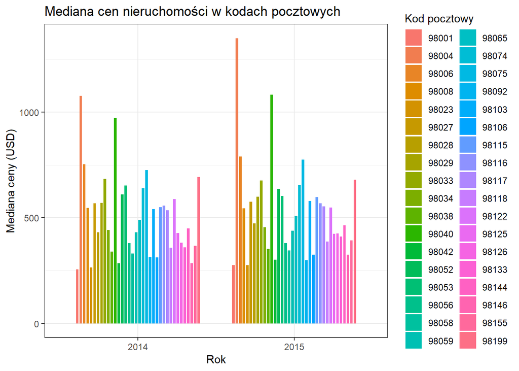

```r
# Tu umieść kod do wygenerowania odpowiedzi do zadania.
df$year <- as.numeric(format(substr(df$date, 1, 4)))


zip_counts <- df %>%
  group_by(zipcode) %>%
  summarise(n=n()) %>%
  filter(n > 280)


df_filtered <- df %>%
  filter(zipcode %in% zip_counts$zipcode)


df_summary <- df_filtered %>%
  group_by(zipcode, year) %>%
  summarise(
    median_price = median(price),
    sd_price = sd(price)
  )


ggplot(df_summary, aes(x = factor(year), y = median_price/1000, fill = factor(zipcode))) +
  geom_bar(stat = "identity", position = position_dodge(width = 0.8), width = 0.6) +
  labs(
    title = "Mediana cen nieruchomości w kodach pocztowych",
    x = "Rok",
    y = "Mediana ceny (USD)",
    fill = "Kod pocztowy"
  ) +
  theme_bw()
```

**Komentarz: Mamy wyraźne różnice w medianach cen pomiędzy poszczególnymi kodami. Niektóre regiony mają znacznie wyższe mediany cen, co może sugerować większe zapotrzebowanie lub wyższą wartość rynkową nieruchomości. Wahania między latami są jednak niewielkie, można zauważyć w przypadku większości kodów lekki wzrost lub utrzymanie ceny.**

## Zadanie 2

Czy jest różnica w rozkładzie ceny nierchomości od powierzchni mieszkalnej uwzględniając podział na nieruchomości z piwnicą i bez?

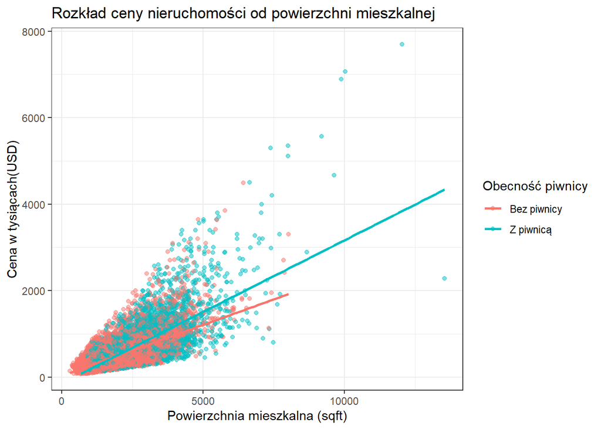

```r
# Tu umieść kod do wygenerowania odpowiedzi do zadania.
df <- df %>%
  mutate(has_basement = ifelse(sqft_basement > 0, "Z piwnicą", "Bez piwnicy"))


ggplot(df, aes(x = sqft_living, y = price/1000, color = has_basement)) +
  geom_point(alpha = 0.5) +
  geom_smooth(method = "lm", se = FALSE) +
  labs(title = "Rozkład ceny nieruchomości od powierzchni mieszkalnej",
       x = "Powierzchnia mieszkalna (sqft)",
       y = "Cena w tysiącach(USD)",
       color = "Obecność piwnicy")+
  theme_bw()
```

**Komentarz: Wyniki wykazują, że ceny nieruchomości wzrastają wraz ze zwiększaniem powierzchni mieszkalnej. Nieruchomości z piwnicą przeważnie mają wyższe ceny w porównaniu do tych bez piwnicy przy podobnej powierzchni mieszkalnej. Linia trendu dla obu grup pokazuje dodatnią korelację między powierzchnią mieszkalną a ceną, jednak nieruchomości z piwnicą wykazują bardziej strome nachylenie, co sugeruje wyższe ceny za większą powierzchnię mieszkalną.**

## Zadanie 3

Jaka jest zależność pomiędzy jakością wykończenia nieruchomości a liczbą pięter?

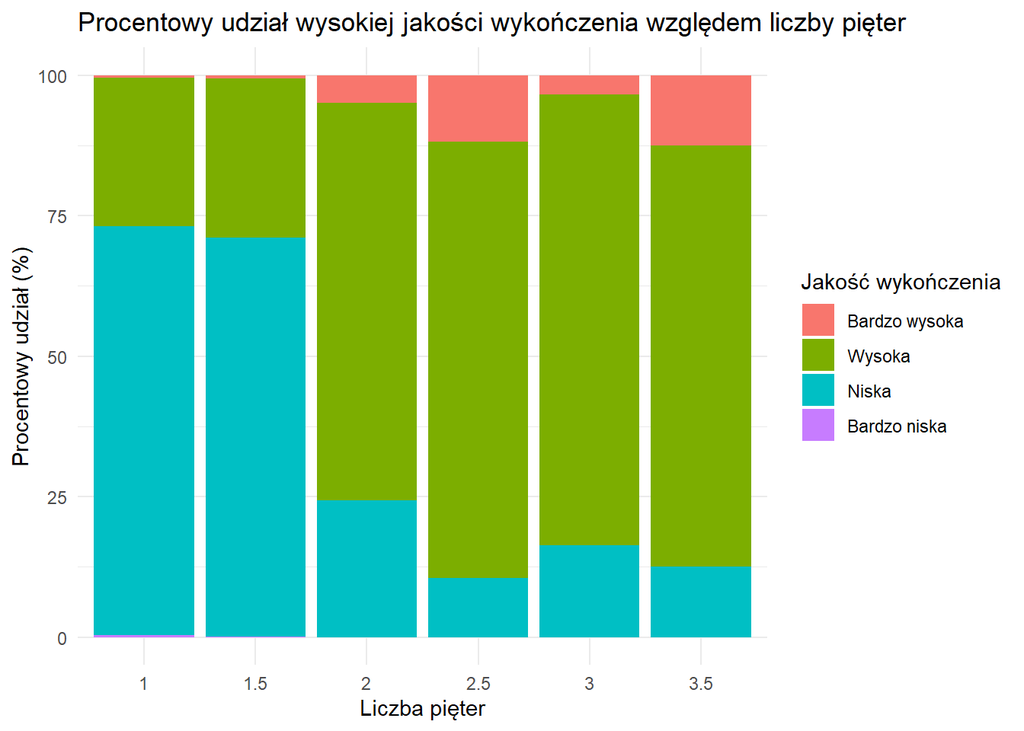

```r
# Tu umieść kod do wygenerowania odpowiedzi do zadania.
df_quality <- df %>%
  mutate(quality_category = case_when(
    grade >= 1 & grade <= 4 ~ "Bardzo niska",
    grade >= 5 & grade <= 7 ~ "Niska",
    grade >= 8 & grade <= 10 ~ "Wysoka",
    grade >= 11 ~ "Bardzo wysoka"
  )) %>%
  group_by(floors, quality_category) %>%
  mutate(
    quality_category = factor(quality_category, levels = c("Bardzo wysoka","Wysoka", "Niska","Bardzo niska"))
  ) %>%
  summarise(n=n()) %>%
  group_by(floors) %>%
  mutate(percentage = n / sum(n) * 100)


ggplot(df_quality, aes(x = factor(floors), y = percentage, fill = quality_category)) +
  geom_bar(stat = "identity", position = "stack") +
  labs(title = "Procentowy udział wysokiej jakości wykończenia względem liczby pięter",
       x = "Liczba pięter",
       y = "Procentowy udział (%)",
       fill = "Jakość wykończenia") +
  theme_minimal()
```

## Zadanie 4

Jaka jest zależność między powierzchnią mieszkalną nieruchomości a powierzchnią gruntu w podziale na liczbę sypialni?

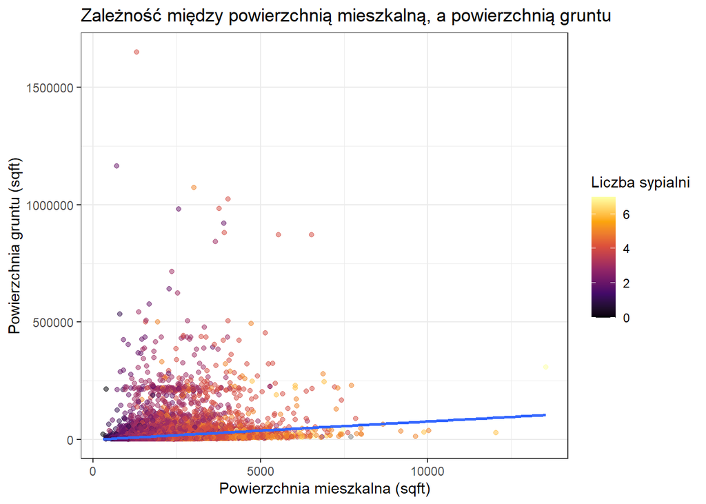

```r
# Tu umieść kod do wygenerowania odpowiedzi do zadania.
ggplot(df, aes(x = sqft_living, y = sqft_lot)) +
  geom_point(aes(color = bedrooms), alpha = 0.5) +
  geom_smooth(method = "lm", se = FALSE) +
  scale_color_viridis_c(option = "inferno", name = "Liczba sypialni", limits = c(0,7)) +
  labs(title = "Zależność między powierzchnią mieszkalną, a powierzchnią gruntu",
       x = "Powierzchnia mieszkalna (sqft)",
       y = "Powierzchnia gruntu (sqft)") +
  theme_bw()
```

## Zadanie 5

Rozważmy tylko nieruchomości, które miały remont. W której dekadzie było najwięcej przeprowadzonych remontów? Czy w poszczególnych dekadach jest porównywalny procent nieruchmości dla każdej wartości miary jakości i wykończenia nieruchomości?

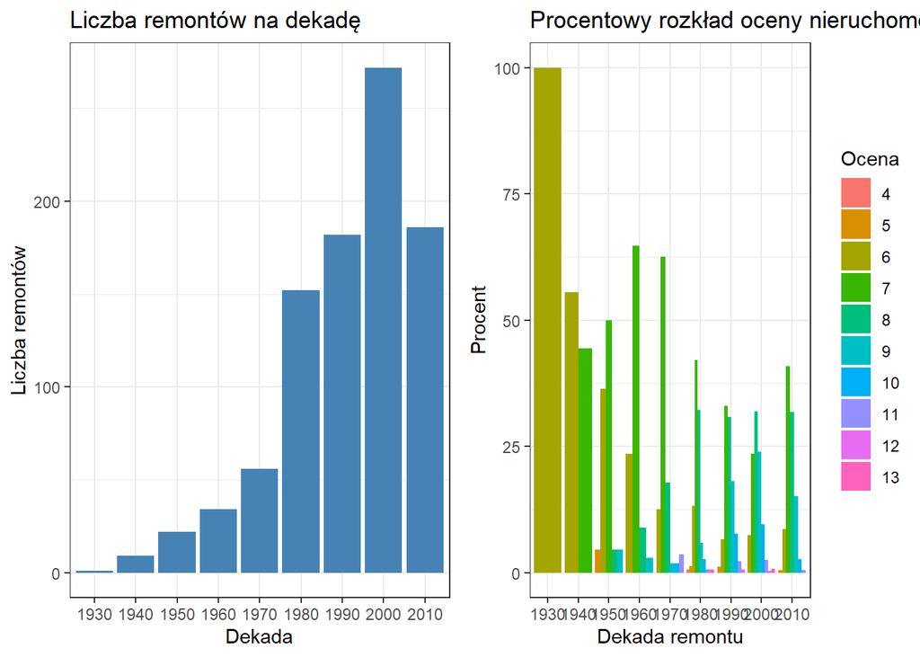

```r
# Tu umieść kod do wygenerowania odpowiedzi do zadania.
df_5.1 <- df %>%
  filter(yr_renovated != 0) %>%
  mutate(dekada_remontu = floor(yr_renovated / 10) * 10) %>%
  count(dekada_remontu) %>%
  arrange(desc(n))

a <-ggplot(df_5.1, aes(x = factor(dekada_remontu), y = n)) +
  geom_bar(stat = "identity", fill = "steelblue") +
  labs(x = "Dekada", y = "Liczba remontów", title = "Liczba remontów na dekadę") +
  theme_bw()
df_5.2 <- df %>%
  filter(yr_renovated != 0) %>%
  mutate(dekada_remontu = floor(yr_renovated / 10) * 10)
grade_counts <- df_5.2 %>%
  group_by(dekada_remontu, grade) %>%
  summarise(count = n()) %>%
  mutate(percent = count / sum(count) * 100)
b<-ggplot(grade_counts, aes(x = factor(dekada_remontu), y = percent, fill = factor(grade))) +
  geom_bar(stat = "identity", position = "dodge") +
  labs(x = "Dekada remontu", y = "Procent", fill = "Ocena") +
  ggtitle("Procentowy rozkład oceny nieruchomości") +
  theme_bw()

library(gridExtra)
grid.arrange(a, b, ncol = 2)
```

**Komentarz: Znaczny wzrost liczby remontów odnotowano w dekadach od lat 80., co może wskazywać na większą potrzebę odnowienia starszych nieruchomości w tamtym czasie. Oceny wykończenia wskazują, że wyższe oceny są bardziej powszechne w budynkach mających niedawno remont, co sugeruje wzrost standardów wykończenia z biegiem czasu.**

## Zadanie 6

Jak prezentuje się wartość minimalna, średnia i maksymalna ceny nieruchmości w podziele na rok budowy nieruchomości.

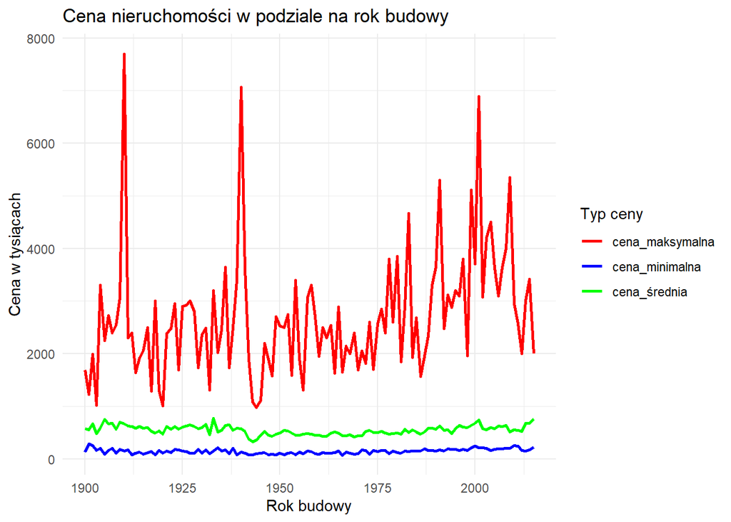

```r
# Tu umieść kod do wygenerowania odpowiedzi do zadania.
price_summary <- df %>%
  group_by(yr_built) %>%
  summarise(
    cena_minimalna = min(price, na.rm = TRUE),
    cena_średnia = mean(price, na.rm = TRUE),
    cena_maksymalna = max(price, na.rm = TRUE)
  )
library(tidyr)

price_summary_long <- price_summary %>%
  pivot_longer(cols = c(cena_minimalna, cena_średnia, cena_maksymalna),
               names_to = "price_type",
               values_to = "price")


ggplot(price_summary_long, aes(x = yr_built, y = price/1000, color = price_type)) +
  geom_line(size = 1) +
  labs(
    title = "Cena nieruchomości w podziale na rok budowy",
    x = "Rok budowy",
    y = "Cena w tysiącach",
    color = "Typ ceny"
  ) +
  theme_minimal() +
  scale_color_manual(values = c("cena_minimalna" = "blue", "cena_średnia" = "green", "cena_maksymalna" = "red"))
```